# GAGA Collection Progress Report 2021

# 1 Overall progress

GAGA aims to generate high quality genomic and other resources (i.e. reference genomes, gene expression data, phenotypic and life history records) for ca. 200 ant species, broadly covering genomic and phenotypic diversity of ants. We have made good progress over the last couple of months have finished sequencing and assembly of over 100 genomes and will now start genome annotation and comparative analyses.

In our first phase collection efforts, **580 samples of 288 species from 131 genera have been collected**. Sample collection has been a global effort, **involving 59 collectors in 32 countries**. Table 1.1 gives an overview of the number of species sampled per subfamily so far. Antwiki.org recognizes 347 genera in the Formicidae, so there is a substantial proportion of ant biodiversity that we could not include as of yet.

Table 1.1: Number of species collected per subfamily.

| Subfamily | freq |
| --- | --- |
| Total | 288 |
| Amblyoponinae | 10 |
| Dolichoderinae | 10 |
| Dorylinae | 10 |
| Ectatomminae | 5 |
| Formicinae | 70 |
| Leptanillinae | 1 |
| Myrmeciinae | 3 |
| Myrmicinae | 119 |
| Paraponerinae | 1 |
| Ponerinae | 45 |
| Proceratiinae | 7 |
| Pseudomyrmecinae | 7 |

We are still eager to secure more samples, in particular from regions we have so far not covered properly (e.g. **Australia**, **Africa**, **Central Asia**). Figure 1.1 gives an overview of the sampling localities we have accessed so far. Overall, however, we are approaching our goal to establish genomic resources for ants on a worldwide scale.

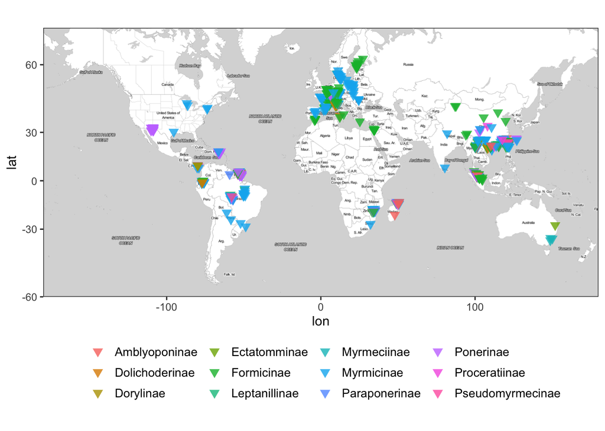

Figure 1.1: Sampling localities of all GAGA samples

# 2 The first 100 GAGA ant genomes

**So far, we could generate long-read PacBio data for 126 species**. Sample biomass, sample quality, and species specific issues in DNA extraction remain the main challenges that need to be overcome before we can attempt long read sequencing. We thus had to give up on a number of species on our preliminary target list and switch to a different species for genome sequencing.

To be able to get genomes also for very rare species, we are now starting to generate assemblies from short-read stLFR/10X sequencing data only, allowing us to **tackle species where only very little biomass is available (e.g. *Leptanilla*)**.

The first 100 genomes that we have generated are biased towards myrmicine and formicine ants, well reflecting differences in species-richness between subfamilies. However, we aim to generate representative genomes for as many subfamilies as possible. See Figure 2.1 for the sampling localities of all so far sequenced species.

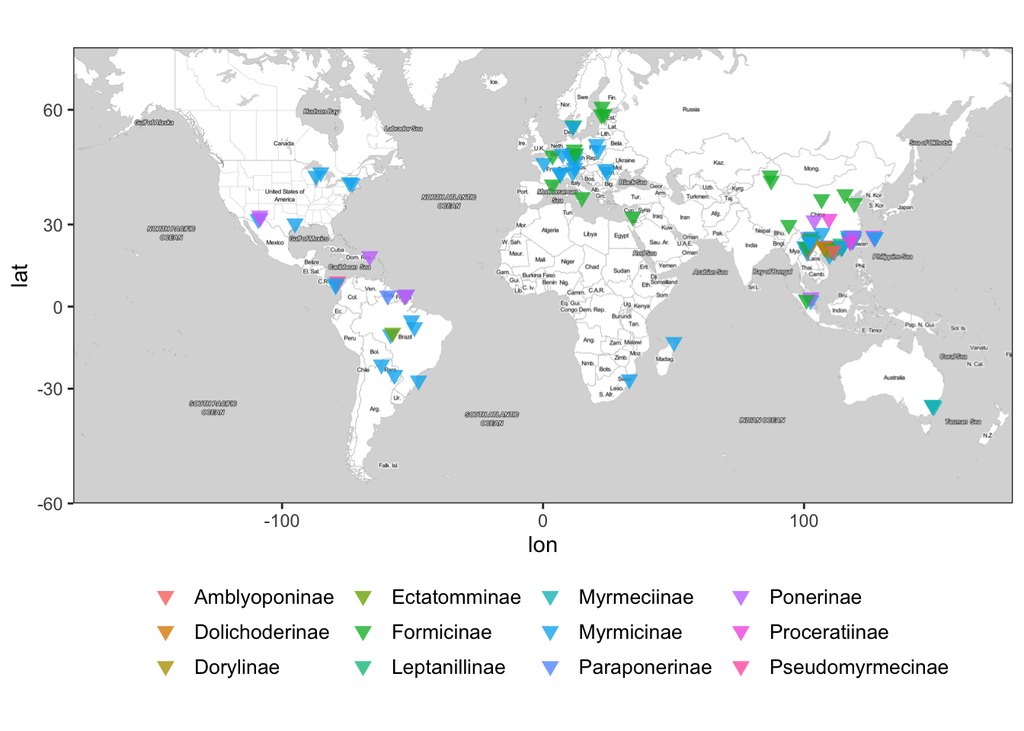

Figure 2.1: Sampling localities of sequenced GAGA species